# Exploratory Data Analysis Report

Report by dlookr package

2020-10-27

# 1 Introduction

The EDA Report provides exploratory data analysis information on objects that inherit data.frame and data.frame.

## 1.1 Information of Dataset

The dataset that generated the EDA Report is an **‘data.frame’** object. It consists of **204 observations** and **26 variables**.

## 1.2 Information of Variables

The variable information of the data set that generated the EDA Report is shown in the following table.:

Information of Variables

| variables | types | missing_count | missing_percent | unique_count | unique_rate |
| --- | --- | --- | --- | --- | --- |
| X3 | numeric | 0 | 0 | 6 | 0.0294118 |
| X. | numeric | 0 | 0 | 52 | 0.2549020 |
| alfa.romero | numeric | 0 | 0 | 22 | 0.1078431 |
| gas | numeric | 0 | 0 | 2 | 0.0098039 |
| std | numeric | 0 | 0 | 2 | 0.0098039 |
| two | numeric | 0 | 0 | 3 | 0.0147059 |
| convertible | numeric | 0 | 0 | 5 | 0.0245098 |
| rwd | numeric | 0 | 0 | 3 | 0.0147059 |
| front | numeric | 0 | 0 | 2 | 0.0098039 |
| X88.6 | numeric | 0 | 0 | 53 | 0.2598039 |
| X168.8 | numeric | 0 | 0 | 75 | 0.3676471 |
| X64.1 | numeric | 0 | 0 | 44 | 0.2156863 |
| X48.8 | numeric | 0 | 0 | 49 | 0.2401961 |
| X2548 | numeric | 0 | 0 | 171 | 0.8382353 |
| dohc | numeric | 0 | 0 | 7 | 0.0343137 |
| four | numeric | 0 | 0 | 7 | 0.0343137 |
| X130 | numeric | 0 | 0 | 44 | 0.2156863 |
| mpfi | numeric | 0 | 0 | 8 | 0.0392157 |
| X3.47 | numeric | 0 | 0 | 39 | 0.1911765 |
| X2.68 | numeric | 0 | 0 | 37 | 0.1813725 |
| X9 | numeric | 0 | 0 | 32 | 0.1568627 |
| X111 | numeric | 0 | 0 | 60 | 0.2941176 |
| X5000 | numeric | 0 | 0 | 24 | 0.1176471 |
| X21 | numeric | 0 | 0 | 29 | 0.1421569 |
| X27 | numeric | 0 | 0 | 30 | 0.1470588 |
| X13495 | numeric | 0 | 0 | 186 | 0.9117647 |

The target variable of the data is **‘X88.6’**, and the data type of the variable is **numeric**.

## 1.3 About EDA Report

EDA reports provide information and visualization results that support the EDA process. In particular, it provides a variety of information to understand the relationship between the target variable and the rest of the variables of interest.

# 2 Univariate Analysis

## 2.1 Descriptive Statistics

edaData  
26 Variables 204 Observations

X3

| n | missing | distinct | Info | Mean | Gmd |
| --- | --- | --- | --- | --- | --- |
| 204 | 0 | 6 | 0.939 | 0.8235 | 1.375 |

lowest : -2 -1 0 1 2 , highest: -1 0 1 2 3

```
 Value         -2    -1     0     1     2     3
 Frequency      3    22    67    54    32    26
 Proportion 0.015 0.108 0.328 0.265 0.157 0.127
```

X.

| n | missing | distinct | Info | Mean | Gmd | .05 | .10 | .25 | .50 | .75 | .90 | .95 |
| --- | --- | --- | --- | --- | --- | --- | --- | --- | --- | --- | --- | --- |
| 204 | 0 | 52 | 0.992 | 21.55 | 19.4 | 1.00 | 1.00 | 4.00 | 20.00 | 36.25 | 48.00 | 49.85 |

lowest : 1 2 3 4 5 , highest: 48 49 50 51 52

alfa.romero

| n | missing | distinct | Info | Mean | Gmd | .05 | .10 | .25 | .50 | .75 | .90 | .95 |
| --- | --- | --- | --- | --- | --- | --- | --- | --- | --- | --- | --- | --- |
| 204 | 0 | 22 | 0.993 | 13.25 | 7.136 | 3.00 | 5.00 | 9.00 | 13.00 | 20.00 | 21.00 | 21.85 |

lowest : 1 2 3 4 5 , highest: 18 19 20 21 22

gas

| n | missing | distinct | Info | Mean | Gmd |
| --- | --- | --- | --- | --- | --- |
| 204 | 0 | 2 | 0.265 | 1.902 | 0.1777 |

```
 Value          1     2
 Frequency     20   184
 Proportion 0.098 0.902
```

std

| n | missing | distinct | Info | Mean | Gmd |
| --- | --- | --- | --- | --- | --- |
| 204 | 0 | 2 | 0.445 | 1.181 | 0.2984 |

```
 Value          1     2
 Frequency    167    37
 Proportion 0.819 0.181
```

two

| n | missing | distinct | Info | Mean | Gmd |
| --- | --- | --- | --- | --- | --- |
| 204 | 0 | 3 | 0.745 | 2.422 | 0.5125 |

```
 Value          1     2     3
 Frequency      2   114    88
 Proportion 0.010 0.559 0.431
```

convertible

| n | missing | distinct | Info | Mean | Gmd |
| --- | --- | --- | --- | --- | --- |
| 204 | 0 | 5 | 0.853 | 3.627 | 0.8691 |

lowest : 1 2 3 4 5 , highest: 1 2 3 4 5

```
 Value          1     2     3     4     5
 Frequency      5     8    70    96    25
 Proportion 0.025 0.039 0.343 0.471 0.123
```

rwd

| n | missing | distinct | Info | Mean | Gmd |
| --- | --- | --- | --- | --- | --- |
| 204 | 0 | 3 | 0.747 | 2.324 | 0.552 |

```
 Value          1     2     3
 Frequency      9   120    75
 Proportion 0.044 0.588 0.368
```

front

| n | missing | distinct | Info | Mean | Gmd |
| --- | --- | --- | --- | --- | --- |
| 204 | 0 | 2 | 0.043 | 1.015 | 0.02912 |

```
 Value          1     2
 Frequency    201     3
 Proportion 0.985 0.015
```

X88.6

| n | missing | distinct | Info | Mean | Gmd | .05 | .10 | .25 | .50 | .75 | .90 | .95 |
| --- | --- | --- | --- | --- | --- | --- | --- | --- | --- | --- | --- | --- |
| 204 | 0 | 53 | 0.997 | 98.81 | 6.395 | 93.1 | 93.7 | 94.5 | 97.0 | 102.4 | 107.9 | 110.0 |

lowest : 86.6 88.4 88.6 89.5 91.3 , highest: 112.0 113.0 114.2 115.6 120.9

X168.8

| n | missing | distinct | Info | Mean | Gmd | .05 | .10 | .25 | .50 | .75 | .90 | .95 |
| --- | --- | --- | --- | --- | --- | --- | --- | --- | --- | --- | --- | --- |
| 204 | 0 | 75 | 0.999 | 174.1 | 13.89 | 157.1 | 157.3 | 166.3 | 173.2 | 183.2 | 188.8 | 196.5 |

lowest : 141.1 144.6 150.0 155.9 156.9 , highest: 198.9 199.2 199.6 202.6 208.1

X64.1

| n | missing | distinct | Info | Mean | Gmd | .05 | .10 | .25 | .50 | .75 | .90 | .95 |
| --- | --- | --- | --- | --- | --- | --- | --- | --- | --- | --- | --- | --- |
| 204 | 0 | 44 | 0.996 | 65.92 | 2.333 | 63.60 | 63.80 | 64.07 | 65.50 | 66.90 | 68.68 | 70.47 |

lowest : 60.3 61.8 62.5 63.4 63.6 , highest: 70.9 71.4 71.7 72.0 72.3

X48.8

| n | missing | distinct | Info | Mean | Gmd | .05 | .10 | .25 | .50 | .75 | .90 | .95 |
| --- | --- | --- | --- | --- | --- | --- | --- | --- | --- | --- | --- | --- |
| 204 | 0 | 49 | 0.999 | 53.75 | 2.761 | 49.77 | 50.60 | 52.00 | 54.10 | 55.50 | 56.64 | 57.50 |

lowest : 47.8 48.8 49.4 49.6 49.7 , highest: 57.5 58.3 58.7 59.1 59.8

X2548

| n | missing | distinct | Info | Mean | Gmd | .05 | .10 | .25 | .50 | .75 | .90 | .95 |
| --- | --- | --- | --- | --- | --- | --- | --- | --- | --- | --- | --- | --- |
| 204 | 0 | 171 | 1 | 2556 | 584.9 | 1901 | 1946 | 2145 | 2414 | 2939 | 3230 | 3504 |

lowest : 1488 1713 1819 1837 1874 , highest: 3750 3770 3900 3950 4066

dohc

| n | missing | distinct | Info | Mean | Gmd |
| --- | --- | --- | --- | --- | --- |
| 204 | 0 | 7 | 0.617 | 4.029 | 0.8804 |

lowest : 1 2 3 4 5 , highest: 3 4 5 6 7

```
 Value          1     2     3     4     5     6     7
 Frequency     11     1    12   148    15    13     4
 Proportion 0.054 0.005 0.059 0.725 0.074 0.064 0.020
```

four

| n | missing | distinct | Info | Mean | Gmd |
| --- | --- | --- | --- | --- | --- |
| 204 | 0 | 7 | 0.534 | 3.118 | 0.5895 |

lowest : 1 2 3 4 5 , highest: 3 4 5 6 7

```
 Value          1     2     3     4     5     6     7
 Frequency      5    11   158    24     1     1     4
 Proportion 0.025 0.054 0.775 0.118 0.005 0.005 0.020
```

X130

| n | missing | distinct | Info | Mean | Gmd | .05 | .10 | .25 | .50 | .75 | .90 | .95 |
| --- | --- | --- | --- | --- | --- | --- | --- | --- | --- | --- | --- | --- |
| 204 | 0 | 44 | 0.998 | 126.9 | 41.81 | 90.0 | 91.0 | 97.0 | 119.5 | 142.0 | 181.0 | 201.6 |

lowest : 61 70 79 80 90 , highest: 234 258 304 308 326

mpfi

| n | missing | distinct | Info | Mean | Gmd |
| --- | --- | --- | --- | --- | --- |
| 204 | 0 | 8 | 0.87 | 4.245 | 2.162 |

lowest : 1 2 3 4 5 , highest: 4 5 6 7 8

```
 Value          1     2     3     4     5     6     7     8
 Frequency     11    66     3    20     1    93     9     1
 Proportion 0.054 0.324 0.015 0.098 0.005 0.456 0.044 0.005
```

X3.47

| n | missing | distinct | Info | Mean | Gmd | .05 | .10 | .25 | .50 | .75 | .90 | .95 |
| --- | --- | --- | --- | --- | --- | --- | --- | --- | --- | --- | --- | --- |
| 204 | 0 | 39 | 0.996 | 19.55 | 11.91 | 4.00 | 6.00 | 11.75 | 18.00 | 28.25 | 33.70 | 37.00 |

lowest : 1 2 3 4 5 , highest: 35 36 37 38 39

X2.68

| n | missing | distinct | Info | Mean | Gmd | .05 | .10 | .25 | .50 | .75 | .90 | .95 |
| --- | --- | --- | --- | --- | --- | --- | --- | --- | --- | --- | --- | --- |
| 204 | 0 | 37 | 0.997 | 20.9 | 10.22 | 5.00 | 7.30 | 14.75 | 23.00 | 27.00 | 32.00 | 34.00 |

lowest : 1 2 3 4 5 , highest: 33 34 35 36 37

X9

| n | missing | distinct | Info | Mean | Gmd | .05 | .10 | .25 | .50 | .75 | .90 | .95 |
| --- | --- | --- | --- | --- | --- | --- | --- | --- | --- | --- | --- | --- |
| 204 | 0 | 32 | 0.986 | 10.15 | 2.941 | 7.500 | 8.000 | 8.575 | 9.000 | 9.400 | 11.080 | 21.840 |

lowest : 7.0 7.5 7.6 7.7 7.8 , highest: 21.9 22.0 22.5 22.7 23.0

X111

| n | missing | distinct | Info | Mean | Gmd | .05 | .10 | .25 | .50 | .75 | .90 | .95 |
| --- | --- | --- | --- | --- | --- | --- | --- | --- | --- | --- | --- | --- |
| 204 | 0 | 60 | 0.998 | 33.27 | 21.21 | 4.0 | 6.0 | 14.0 | 40.5 | 48.0 | 55.7 | 59.0 |

lowest : 1 2 3 4 5 , highest: 56 57 58 59 60

X5000

| n | missing | distinct | Info | Mean | Gmd | .05 | .10 | .25 | .50 | .75 | .90 | .95 |
| --- | --- | --- | --- | --- | --- | --- | --- | --- | --- | --- | --- | --- |
| 204 | 0 | 24 | 0.985 | 13.38 | 6.042 | 3.00 | 6.00 | 10.00 | 14.00 | 18.00 | 20.70 | 22.85 |

lowest : 1 2 3 4 5 , highest: 20 21 22 23 24

X21

| n | missing | distinct | Info | Mean | Gmd | .05 | .10 | .25 | .50 | .75 | .90 | .95 |
| --- | --- | --- | --- | --- | --- | --- | --- | --- | --- | --- | --- | --- |
| 204 | 0 | 29 | 0.993 | 25.24 | 7.298 | 16.0 | 17.0 | 19.0 | 24.0 | 30.0 | 31.7 | 37.0 |

lowest : 13 14 15 16 17 , highest: 37 38 45 47 49

X27

| n | missing | distinct | Info | Mean | Gmd | .05 | .10 | .25 | .50 | .75 | .90 | .95 |
| --- | --- | --- | --- | --- | --- | --- | --- | --- | --- | --- | --- | --- |
| 204 | 0 | 30 | 0.996 | 30.77 | 7.704 | 22.00 | 23.00 | 25.00 | 30.00 | 34.50 | 38.00 | 42.85 |

lowest : 16 17 18 19 20 , highest: 46 47 50 53 54

X13495

| n | missing | distinct | Info | Mean | Gmd | .05 | .10 | .25 | .50 | .75 | .90 | .95 |
| --- | --- | --- | --- | --- | --- | --- | --- | --- | --- | --- | --- | --- |
| 204 | 0 | 186 | 1 | 94.48 | 63.11 | 8.15 | 18.30 | 47.75 | 96.50 | 142.25 | 167.00 | 175.85 |

lowest : 1 2 3 4 5 , highest: 182 183 184 185 186

## 2.2 Normality Test of Numerical Variables

### 2.2.1 Statistics and Visualization of (Sample) Data

**[ X3 ]**

normality test : Shapiro-Wilk normality test

```
 statistic : 0.91758,  p-value : 2.959E-09
```

skewness and kurtosis

| type | skewness | kurtosis |
| --- | --- | --- |
| original | 0.2131672 | 2.330470 |
| log transformation | NaN | NaN |
| sqrt transformation | -0.1289829 | 1.461527 |

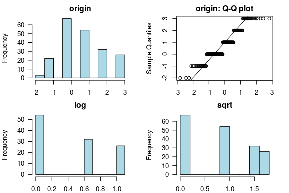

**[ X. ]**

normality test : Shapiro-Wilk normality test

```
 statistic : 0.90512,  p-value : 4.04661E-10
```

skewness and kurtosis

| type | skewness | kurtosis |
| --- | --- | --- |
| original | 0.2736523 | 1.739224 |
| log transformation | -0.7703369 | 2.067665 |
| sqrt transformation | -0.2280880 | 1.663142 |

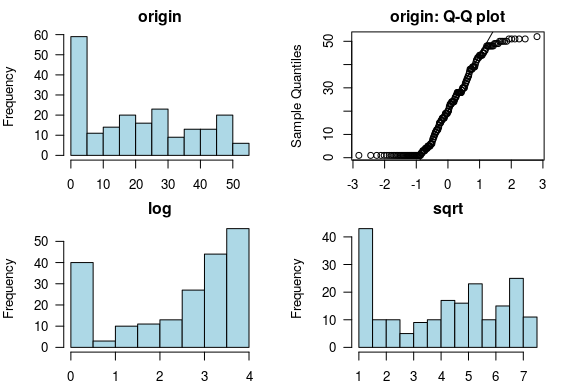

**[ alfa.romero ]**

normality test : Shapiro-Wilk normality test

```
 statistic : 0.92795,  p-value : 1.80064E-08
```

skewness and kurtosis

| type | skewness | kurtosis |
| --- | --- | --- |
| original | -0.2410454 | 1.809847 |
| log transformation | -1.3031498 | 4.309189 |
| sqrt transformation | -0.6591856 | 2.451134 |

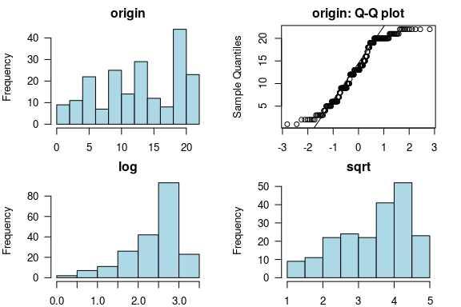

**[ gas ]**

normality test : Shapiro-Wilk normality test

```
 statistic : 0.3382,  p-value : 1.24574E-26
```

skewness and kurtosis

| type | skewness | kurtosis |
| --- | --- | --- |
| original | -2.70346 | 8.308696 |
| log transformation | -2.70346 | 8.308696 |
| sqrt transformation | -2.70346 | 8.308696 |

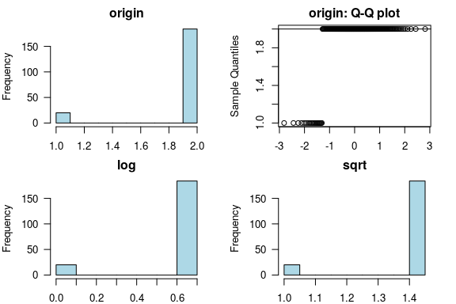

**[ std ]**

normality test : Shapiro-Wilk normality test

```
 statistic : 0.46791,  p-value : 2.38754E-24
```

skewness and kurtosis

| type | skewness | kurtosis |
| --- | --- | --- |
| original | 1.653805 | 3.73507 |
| log transformation | 1.653805 | 3.73507 |
| sqrt transformation | 1.653805 | 3.73507 |

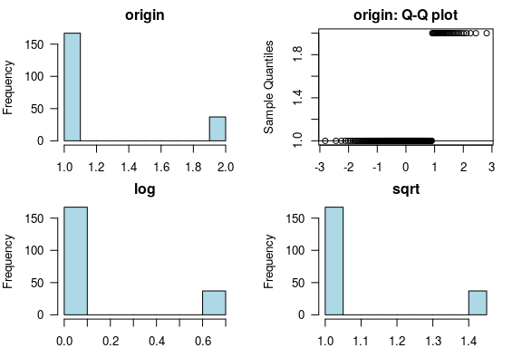

**[ two ]**

normality test : Shapiro-Wilk normality test

```
 statistic : 0.66799,  p-value : 8.73983E-20
```

skewness and kurtosis

| type | skewness | kurtosis |
| --- | --- | --- |
| original | 0.0994817 | 1.526861 |
| log transformation | -0.3055556 | 3.213345 |
| sqrt transformation | -0.0438986 | 2.050747 |

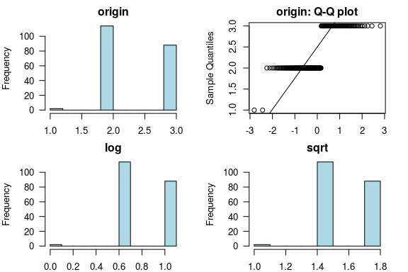

**[ convertible ]**

normality test : Shapiro-Wilk normality test

```
 statistic : 0.84929,  p-value : 2.82023E-13
```

skewness and kurtosis

| type | skewness | kurtosis |
| --- | --- | --- |
| original | -0.6042108 | 3.911254 |
| log transformation | -2.0907453 | 9.715941 |
| sqrt transformation | -1.2465947 | 5.922790 |

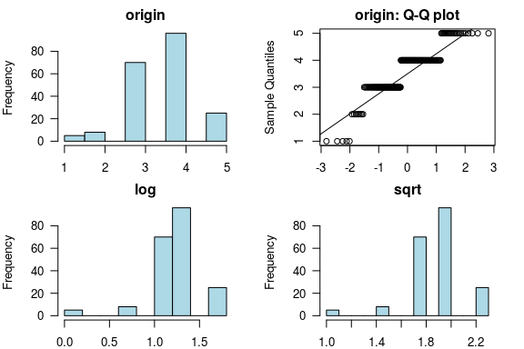

**[ rwd ]**

normality test : Shapiro-Wilk normality test

```
 statistic : 0.71952,  p-value : 2.82196E-18
```

skewness and kurtosis

| type | skewness | kurtosis |
| --- | --- | --- |
| original | -0.0493368 | 2.320214 |
| log transformation | -0.9033942 | 4.760690 |
| sqrt transformation | -0.4028763 | 3.230735 |

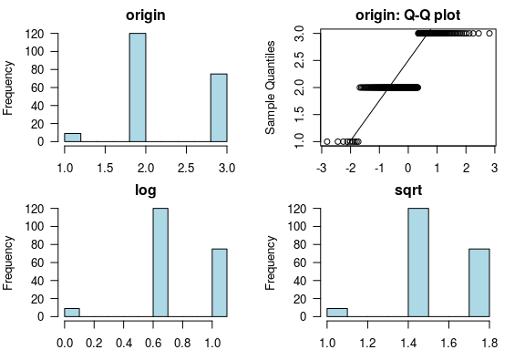

**[ front ]**

normality test : Shapiro-Wilk normality test

```
 statistic : 0.09701,  p-value : 4.53279E-30
```

skewness and kurtosis

| type | skewness | kurtosis |
| --- | --- | --- |
| original | 8.063183 | 66.01493 |
| log transformation | 8.063183 | 66.01493 |
| sqrt transformation | 8.063183 | 66.01493 |

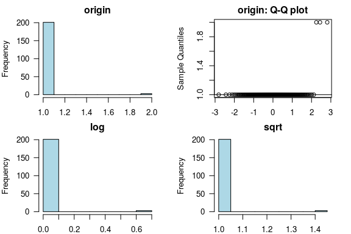

**[ X168.8 ]**

normality test : Shapiro-Wilk normality test

```
 statistic : 0.98232,  p-value : 0.0114913
```

skewness and kurtosis

| type | skewness | kurtosis |
| --- | --- | --- |
| original | 0.1487573 | 2.879597 |
| log transformation | -0.0523130 | 2.926731 |
| sqrt transformation | 0.0490731 | 2.888532 |

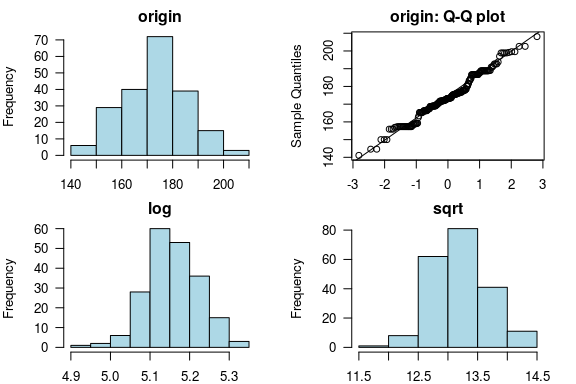

**[ X64.1 ]**

normality test : Shapiro-Wilk normality test

```
 statistic : 0.92207,  p-value : 6.35361E-09
```

skewness and kurtosis

| type | skewness | kurtosis |
| --- | --- | --- |
| original | 0.8904365 | 3.647039 |
| log transformation | 0.8008769 | 3.511395 |
| sqrt transformation | 0.8457476 | 3.576117 |

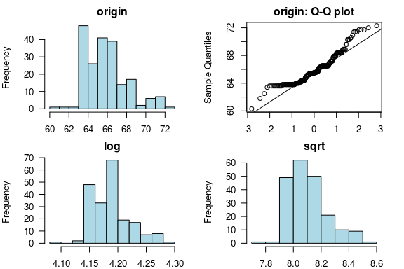

**[ X48.8 ]**

normality test : Shapiro-Wilk normality test

```
 statistic : 0.98365,  p-value : 0.0181391
```

skewness and kurtosis

| type | skewness | kurtosis |
| --- | --- | --- |
| original | 0.0758586 | 2.541767 |
| log transformation | -0.0259512 | 2.490614 |
| sqrt transformation | 0.0246501 | 2.512237 |

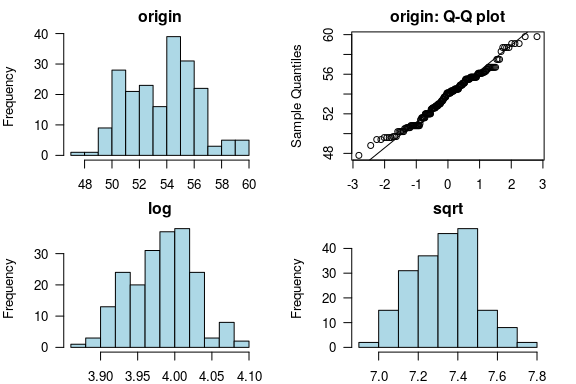

**[ X2548 ]**

normality test : Shapiro-Wilk normality test

```
 statistic : 0.95259,  p-value : 2.74137E-06
```

skewness and kurtosis

| type | skewness | kurtosis |
| --- | --- | --- |
| original | 0.6745378 | 2.914584 |
| log transformation | 0.2687171 | 2.421531 |
| sqrt transformation | 0.4697411 | 2.599234 |

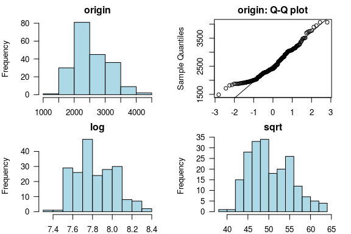

**[ dohc ]**

normality test : Shapiro-Wilk normality test

```
 statistic : 0.70117,  p-value : 7.77995E-19
```

skewness and kurtosis

| type | skewness | kurtosis |
| --- | --- | --- |
| original | -0.4852657 | 6.353492 |
| log transformation | -2.6188814 | 10.917860 |
| sqrt transformation | -1.6392644 | 8.165385 |

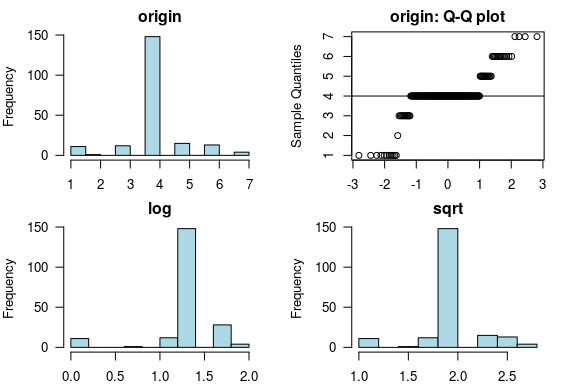

**[ four ]**

normality test : Shapiro-Wilk normality test

```
 statistic : 0.58115,  p-value : 5.71049E-22
```

skewness and kurtosis

| type | skewness | kurtosis |
| --- | --- | --- |
| original | 2.1215247 | 13.72436 |
| log transformation | -1.2179691 | 11.56730 |
| sqrt transformation | 0.5390494 | 10.48445 |

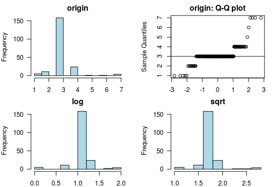

**[ X130 ]**

normality test : Shapiro-Wilk normality test

```
 statistic : 0.82909,  p-value : 3.22457E-14
```

skewness and kurtosis

| type | skewness | kurtosis |
| --- | --- | --- |
| original | 1.9298223 | 8.111533 |
| log transformation | 0.8532489 | 3.942484 |
| sqrt transformation | 1.3535764 | 5.490592 |

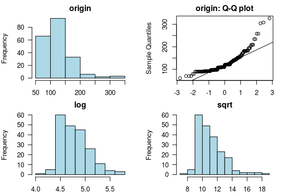

**[ mpfi ]**

normality test : Shapiro-Wilk normality test

```
 statistic : 0.79118,  p-value : 8.59828E-16
```

skewness and kurtosis

| type | skewness | kurtosis |
| --- | --- | --- |
| original | -0.2324055 | 1.353928 |
| log transformation | -0.5918527 | 1.969967 |
| sqrt transformation | -0.3761203 | 1.512307 |

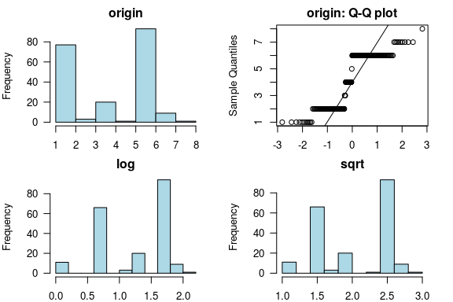

**[ X3.47 ]**

normality test : Shapiro-Wilk normality test

```
 statistic : 0.95408,  p-value : 3.8784E-06
```

skewness and kurtosis

| type | skewness | kurtosis |
| --- | --- | --- |
| original | 0.1374947 | 1.864816 |
| log transformation | -1.3794642 | 5.471363 |
| sqrt transformation | -0.3801794 | 2.371936 |

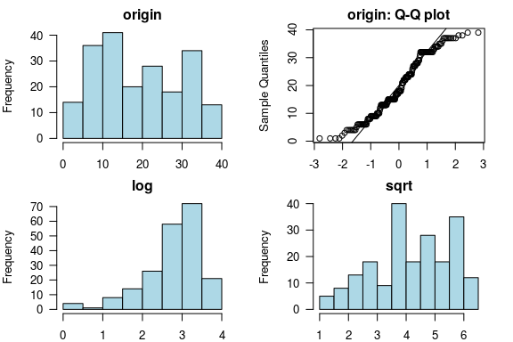

**[ X2.68 ]**

normality test : Shapiro-Wilk normality test

```
 statistic : 0.96241,  p-value : 3.02379E-05
```

skewness and kurtosis

| type | skewness | kurtosis |
| --- | --- | --- |
| original | -0.4019186 | 2.332240 |
| log transformation | -2.0413755 | 7.830313 |
| sqrt transformation | -1.0057082 | 3.498354 |

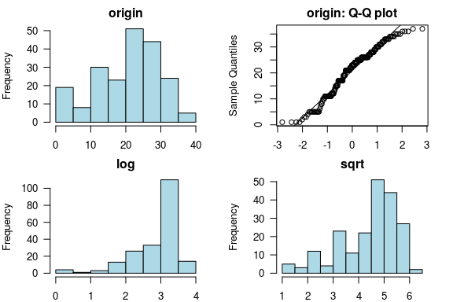

**[ X9 ]**

normality test : Shapiro-Wilk normality test

```
 statistic : 0.49886,  p-value : 9.67907E-24
```

skewness and kurtosis

| type | skewness | kurtosis |
| --- | --- | --- |
| original | 2.582858 | 8.029700 |
| log transformation | 2.324273 | 7.277038 |
| sqrt transformation | 2.478831 | 7.705630 |

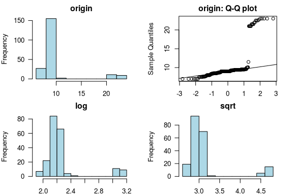

**[ X111 ]**

normality test : Shapiro-Wilk normality test

```
 statistic : 0.91002,  p-value : 8.65843E-10
```

skewness and kurtosis

| type | skewness | kurtosis |
| --- | --- | --- |
| original | -0.2933479 | 1.654662 |
| log transformation | -1.2834384 | 3.901655 |
| sqrt transformation | -0.6619976 | 2.111117 |

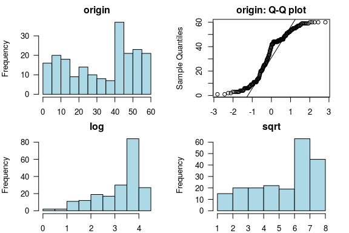

**[ X5000 ]**

normality test : Shapiro-Wilk normality test

```
 statistic : 0.9677,  p-value : 0.000125244
```

skewness and kurtosis

| type | skewness | kurtosis |
| --- | --- | --- |
| original | -0.2033783 | 2.558291 |
| log transformation | -1.8443138 | 7.045052 |
| sqrt transformation | -0.8807358 | 3.682943 |

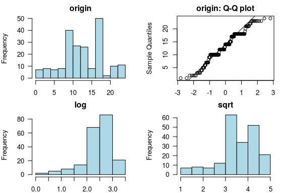

**[ X21 ]**

normality test : Shapiro-Wilk normality test

```
 statistic : 0.9574,  p-value : 8.57177E-06
```

skewness and kurtosis

| type | skewness | kurtosis |
| --- | --- | --- |
| original | 0.6510788 | 3.523568 |
| log transformation | -0.0045412 | 2.546832 |
| sqrt transformation | 0.3066024 | 2.847148 |

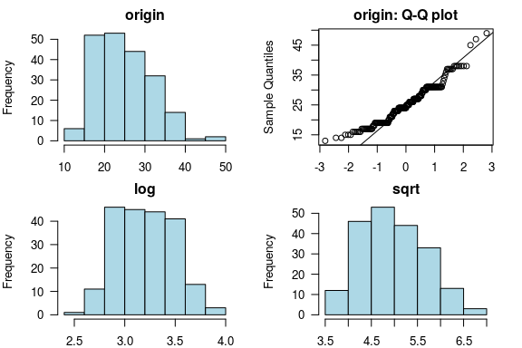

**[ X27 ]**

normality test : Shapiro-Wilk normality test

```
 statistic : 0.9737,  p-value : 0.000715118
```

skewness and kurtosis

| type | skewness | kurtosis |
| --- | --- | --- |
| original | 0.5286810 | 3.387484 |
| log transformation | -0.1276582 | 2.982696 |
| sqrt transformation | 0.1999059 | 3.007157 |

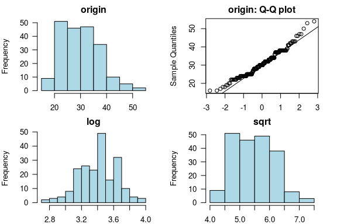

**[ X13495 ]**

normality test : Shapiro-Wilk normality test

```
 statistic : 0.95155,  p-value : 2.15944E-06
```

skewness and kurtosis

| type | skewness | kurtosis |
| --- | --- | --- |
| original | -0.0656246 | 1.778464 |
| log transformation | -1.9401855 | 7.197059 |
| sqrt transformation | -0.6490637 | 2.504781 |

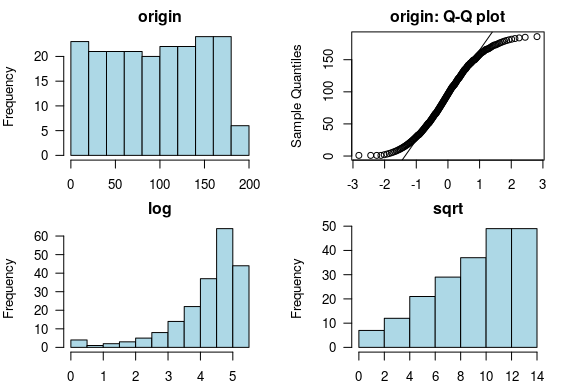

# 3 Relationship Between Variables

## 3.1 Correlation Coefficient

### 3.1.1 Correlation Coefficient by Variable Combination

Table of correlation coefficients (0.5 or more)

| Variable1 | Variable2 | Correlation Coefficient |
| --- | --- | --- |
| X9 | gas | -0.9843527 |
| X27 | X21 | 0.9713115 |
| X2548 | X168.8 | 0.8780901 |
| X168.8 | X88.6 | 0.8776119 |
| X2548 | X64.1 | 0.8684931 |
| X130 | X2548 | 0.8506114 |
| X64.1 | X168.8 | 0.8411992 |
| X27 | X2548 | -0.7980877 |
| X64.1 | X88.6 | 0.7951150 |
| X2548 | X88.6 | 0.7817629 |
| X21 | X2548 | -0.7582376 |
| X130 | X64.1 | 0.7370420 |
| X27 | X168.8 | -0.7066348 |
| X130 | X168.8 | 0.6838298 |
| X27 | X64.1 | -0.6811688 |
| X27 | X130 | -0.6777753 |
| X21 | X168.8 | -0.6732506 |
| convertible | two | -0.6709439 |
| X21 | mpfi | -0.6707558 |
| X21 | X130 | -0.6541014 |
| X21 | X64.1 | -0.6471770 |
| X27 | mpfi | -0.6449983 |
| two | X3 | 0.6426870 |
| X3.47 | X2548 | 0.6420477 |
| X3.47 | X130 | 0.6139346 |
| X3.47 | X168.8 | 0.6131261 |
| mpfi | X2548 | 0.6128415 |
| convertible | X3 | -0.5879255 |
| X48.8 | X88.6 | 0.5826031 |
| X2548 | rwd | 0.5772843 |
| X130 | X88.6 | 0.5739894 |
| X111 | mpfi | -0.5727429 |
| mpfi | X168.8 | 0.5609186 |
| X48.8 | convertible | 0.5566333 |
| X27 | X88.6 | -0.5528967 |
| X3.47 | X64.1 | 0.5425478 |
| X27 | X3.47 | -0.5366165 |
| X48.8 | X3 | -0.5330777 |
| X21 | X3.47 | -0.5272868 |
| mpfi | X64.1 | 0.5269328 |
| X130 | rwd | 0.5257721 |
| X88.6 | X3 | -0.5250949 |
| mpfi | X130 | 0.5147142 |
| X48.8 | two | -0.5117361 |
| X3.47 | X88.6 | 0.5053631 |

### 3.1.2 Correlation Plot of Numerical Variables

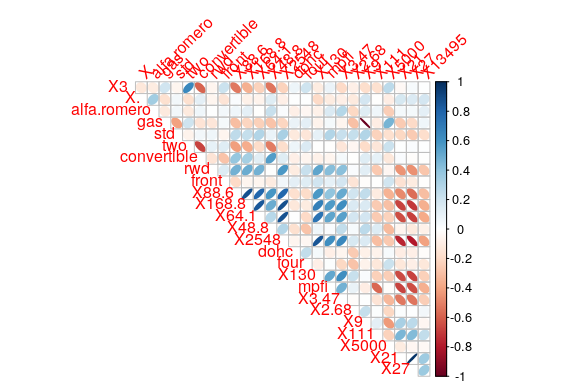

# 4 Target based Analysis

## 4.1 Grouped Descriptive Statistics

### 4.1.1 Grouped Numerical Variables

**[ X3 ]**

Simple Linear Model Information

```
 Residual standard error: 5 on 202 degrees of freedom
 Multiple R-squared:  0.27572,  Adjusted R-squared:  0.27214
 F-statistic: 77 on 1 and 202 DF,  p-value: 7.47030370942711e-16
```

Coefficients:

Simple Linear Model coefficients : X3

|  | Estimate | Std. Error | t value | Pr(>\|t\|) |
| --- | --- | --- | --- | --- |
| (Intercept) | 100.90 | 0.43 | 234.52 | 0 |
| X3 | -2.54 | 0.29 | -8.77 | 0 |

Visualization:

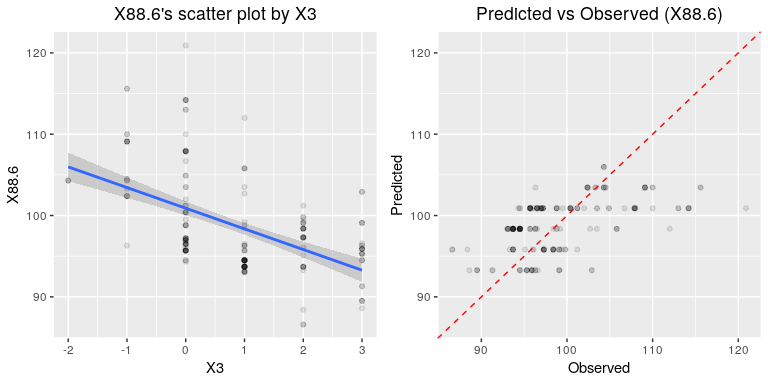

**[ X. ]**

Simple Linear Model Information

```
 Residual standard error: 6 on 202 degrees of freedom
 Multiple R-squared:  0.00088,  Adjusted R-squared:  -0.00407
 F-statistic: 0 on 1 and 202 DF,  p-value: 0.673745338890025
```

Coefficients:

Simple Linear Model coefficients : X.

|  | Estimate | Std. Error | t value | Pr(>\|t\|) |
| --- | --- | --- | --- | --- |
| (Intercept) | 98.58 | 0.68 | 144.78 | 0.00 |
| X. | 0.01 | 0.02 | 0.42 | 0.67 |

Visualization:

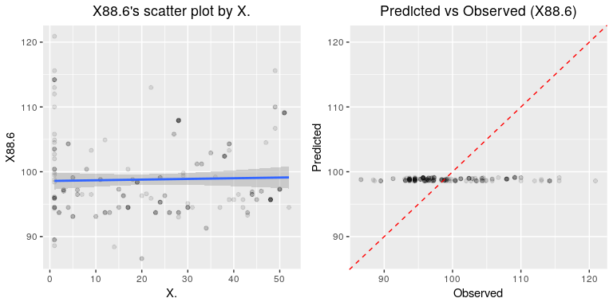

**[ alfa.romero ]**

Simple Linear Model Information

```
 Residual standard error: 6 on 202 degrees of freedom
 Multiple R-squared:  0.00402,  Adjusted R-squared:  -0.00091
 F-statistic: 1 on 1 and 202 DF,  p-value: 0.367717965591981
```

Coefficients:

Simple Linear Model coefficients : alfa.romero

|  | Estimate | Std. Error | t value | Pr(>\|t\|) |
| --- | --- | --- | --- | --- |
| (Intercept) | 98.00 | 0.99 | 99.1 | 0.00 |
| alfa.romero | 0.06 | 0.07 | 0.9 | 0.37 |

Visualization:

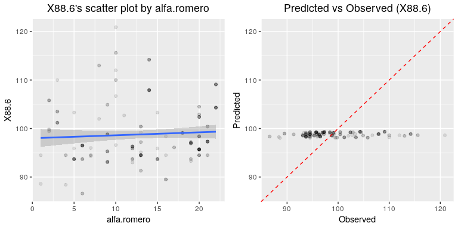

**[ gas ]**

Simple Linear Model Information

```
 Residual standard error: 6 on 202 degrees of freedom
 Multiple R-squared:  0.09478,  Adjusted R-squared:  0.0903
 F-statistic: 21 on 1 and 202 DF,  p-value: 7.48271144422281e-06
```

Coefficients:

Simple Linear Model coefficients : gas

|  | Estimate | Std. Error | t value | Pr(>\|t\|) |
| --- | --- | --- | --- | --- |
| (Intercept) | 110.58 | 2.59 | 42.67 | 0 |
| gas | -6.19 | 1.35 | -4.60 | 0 |

Visualization:

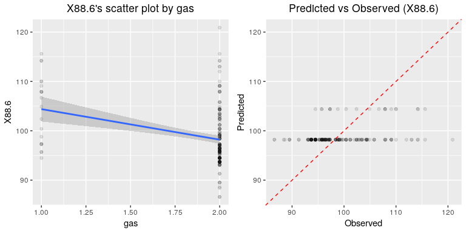

**[ std ]**

Simple Linear Model Information

```
 Residual standard error: 6 on 202 degrees of freedom
 Multiple R-squared:  0.06536,  Adjusted R-squared:  0.06073
 F-statistic: 14 on 1 and 202 DF,  p-value: 0.000223742361041301
```

Coefficients:

Simple Linear Model coefficients : std

|  | Estimate | Std. Error | t value | Pr(>\|t\|) |
| --- | --- | --- | --- | --- |
| (Intercept) | 94.12 | 1.31 | 71.76 | 0 |
| std | 3.97 | 1.06 | 3.76 | 0 |

Visualization:

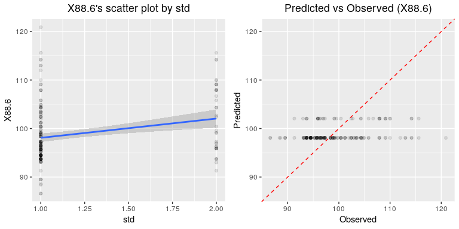

**[ two ]**

Simple Linear Model Information

```
 Residual standard error: 5 on 202 degrees of freedom
 Multiple R-squared:  0.16908,  Adjusted R-squared:  0.16497
 F-statistic: 41 on 1 and 202 DF,  p-value: 1.00070899453666e-09
```

Coefficients:

Simple Linear Model coefficients : two

|  | Estimate | Std. Error | t value | Pr(>\|t\|) |
| --- | --- | --- | --- | --- |
| (Intercept) | 110.41 | 1.85 | 59.70 | 0 |
| two | -4.79 | 0.75 | -6.41 | 0 |

Visualization:

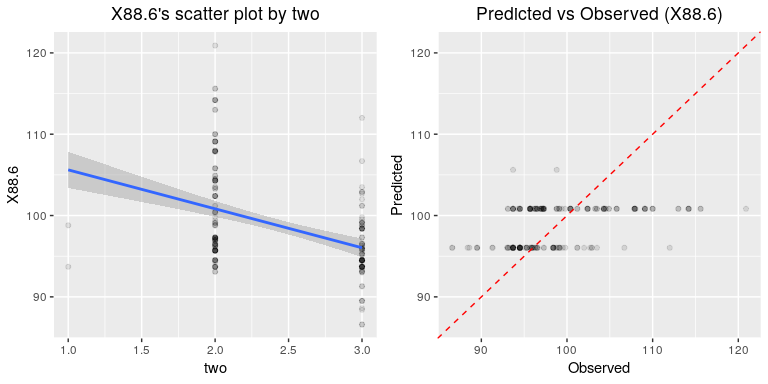

**[ convertible ]**

Simple Linear Model Information

```
 Residual standard error: 6 on 202 degrees of freedom
 Multiple R-squared:  0.1503,   Adjusted R-squared:  0.14609
 F-statistic: 36 on 1 and 202 DF,  p-value: 1.01090724230306e-08
```

Coefficients:

Simple Linear Model coefficients : convertible

|  | Estimate | Std. Error | t value | Pr(>\|t\|) |
| --- | --- | --- | --- | --- |
| (Intercept) | 88.79 | 1.72 | 51.61 | 0 |
| convertible | 2.76 | 0.46 | 5.98 | 0 |

Visualization:

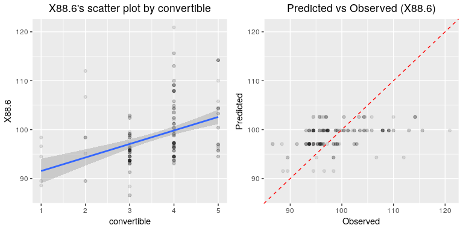

**[ rwd ]**

Simple Linear Model Information

```
 Residual standard error: 5 on 202 degrees of freedom
 Multiple R-squared:  0.22548,  Adjusted R-squared:  0.22164
 F-statistic: 59 on 1 and 202 DF,  p-value: 7.20410640176114e-13
```

Coefficients:

Simple Linear Model coefficients : rwd

|  | Estimate | Std. Error | t value | Pr(>\|t\|) |
| --- | --- | --- | --- | --- |
| (Intercept) | 86.90 | 1.60 | 54.45 | 0 |
| rwd | 5.12 | 0.67 | 7.67 | 0 |

Visualization:

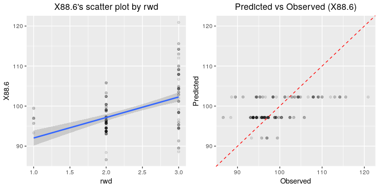

**[ front ]**

Simple Linear Model Information

```
 Residual standard error: 6 on 202 degrees of freedom
 Multiple R-squared:  0.03615,  Adjusted R-squared:  0.03138
 F-statistic: 8 on 1 and 202 DF,  p-value: 0.00644945737606942
```

Coefficients:

Simple Linear Model coefficients : front

|  | Estimate | Std. Error | t value | Pr(>\|t\|) |
| --- | --- | --- | --- | --- |
| (Intercept) | 108.39 | 3.51 | 30.91 | 0.00 |
| front | -9.45 | 3.43 | -2.75 | 0.01 |

Visualization:

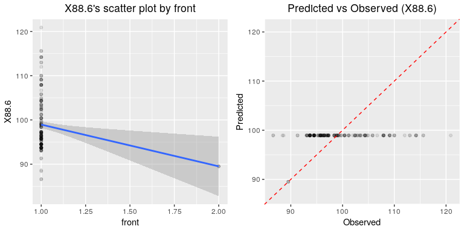

**[ X168.8 ]**

Simple Linear Model Information

```
 Residual standard error: 3 on 202 degrees of freedom
 Multiple R-squared:  0.7702,   Adjusted R-squared:  0.76906
 F-statistic: 677 on 1 and 202 DF,  p-value: 1.99823253147434e-66
```

Coefficients:

Simple Linear Model coefficients : X168.8

|  | Estimate | Std. Error | t value | Pr(>\|t\|) |
| --- | --- | --- | --- | --- |
| (Intercept) | 24.73 | 2.85 | 8.67 | 0 |
| X168.8 | 0.43 | 0.02 | 26.02 | 0 |

Visualization:

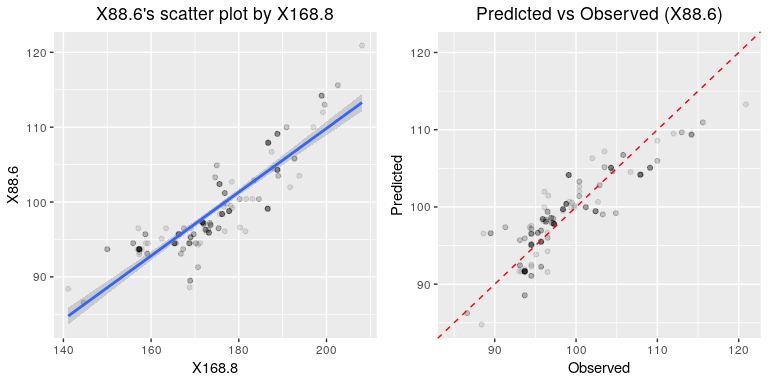

**[ X64.1 ]**

Simple Linear Model Information

```
 Residual standard error: 4 on 202 degrees of freedom
 Multiple R-squared:  0.63221,  Adjusted R-squared:  0.63039
 F-statistic: 347 on 1 and 202 DF,  p-value: 9.395528640016e-46
```

Coefficients:

Simple Linear Model coefficients : X64.1

|  | Estimate | Std. Error | t value | Pr(>\|t\|) |
| --- | --- | --- | --- | --- |
| (Intercept) | -47.54 | 7.86 | -6.05 | 0 |
| X64.1 | 2.22 | 0.12 | 18.63 | 0 |

Visualization:

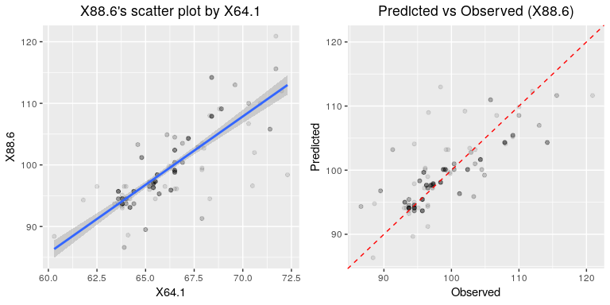

**[ X48.8 ]**

Simple Linear Model Information

```
 Residual standard error: 5 on 202 degrees of freedom
 Multiple R-squared:  0.33943,  Adjusted R-squared:  0.33616
 F-statistic: 104 on 1 and 202 DF,  p-value: 6.18511580884224e-20
```

Coefficients:

Simple Linear Model coefficients : X48.8

|  | Estimate | Std. Error | t value | Pr(>\|t\|) |
| --- | --- | --- | --- | --- |
| (Intercept) | 21.40 | 7.61 | 2.81 | 0.01 |
| X48.8 | 1.44 | 0.14 | 10.19 | 0.00 |

Visualization:

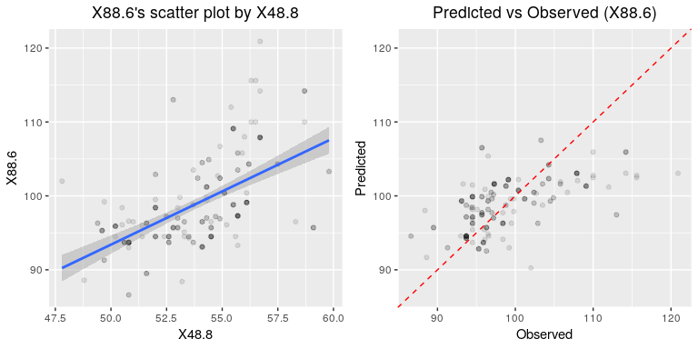

**[ X2548 ]**

Simple Linear Model Information

```
 Residual standard error: 4 on 202 degrees of freedom
 Multiple R-squared:  0.61115,  Adjusted R-squared:  0.60923
 F-statistic: 317 on 1 and 202 DF,  p-value: 2.64205799019475e-43
```

Coefficients:

Simple Linear Model coefficients : X2548

|  | Estimate | Std. Error | t value | Pr(>\|t\|) |
| --- | --- | --- | --- | --- |
| (Intercept) | 75.86 | 1.31 | 57.73 | 0 |
| X2548 | 0.01 | 0.00 | 17.82 | 0 |

Visualization:

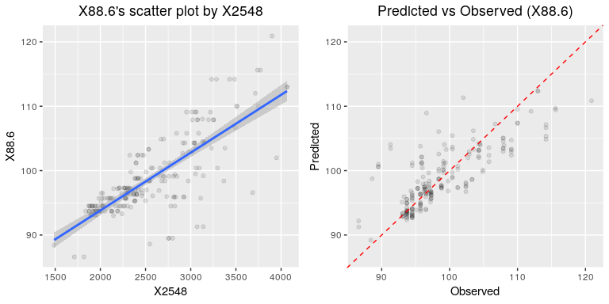

**[ dohc ]**

Simple Linear Model Information

```
 Residual standard error: 6 on 202 degrees of freedom
 Multiple R-squared:  0.02682,  Adjusted R-squared:  0.02201
 F-statistic: 6 on 1 and 202 DF,  p-value: 0.0192471578262543
```

Coefficients:

Simple Linear Model coefficients : dohc

|  | Estimate | Std. Error | t value | Pr(>\|t\|) |
| --- | --- | --- | --- | --- |
| (Intercept) | 102.63 | 1.67 | 61.42 | 0.00 |
| dohc | -0.95 | 0.40 | -2.36 | 0.02 |

Visualization:

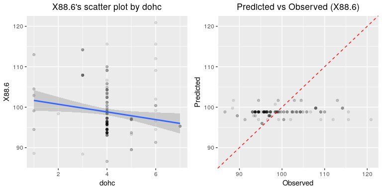

**[ four ]**

Simple Linear Model Information

```
 Residual standard error: 6 on 202 degrees of freedom
 Multiple R-squared:  0.03502,  Adjusted R-squared:  0.03025
 F-statistic: 7 on 1 and 202 DF,  p-value: 0.00735681896336572
```

Coefficients:

Simple Linear Model coefficients : four

|  | Estimate | Std. Error | t value | Pr(>\|t\|) |
| --- | --- | --- | --- | --- |
| (Intercept) | 103.19 | 1.67 | 61.75 | 0.00 |
| four | -1.41 | 0.52 | -2.71 | 0.01 |

Visualization:

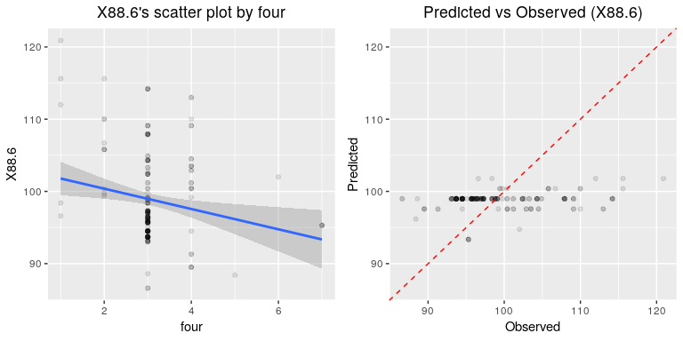

**[ X130 ]**

Simple Linear Model Information

```
 Residual standard error: 5 on 202 degrees of freedom
 Multiple R-squared:  0.32946,  Adjusted R-squared:  0.32614
 F-statistic: 99 on 1 and 202 DF,  p-value: 2.84600718982706e-19
```

Coefficients:

Simple Linear Model coefficients : X130

|  | Estimate | Std. Error | t value | Pr(>\|t\|) |
| --- | --- | --- | --- | --- |
| (Intercept) | 88.35 | 1.10 | 79.96 | 0 |
| X130 | 0.08 | 0.01 | 9.96 | 0 |

Visualization:

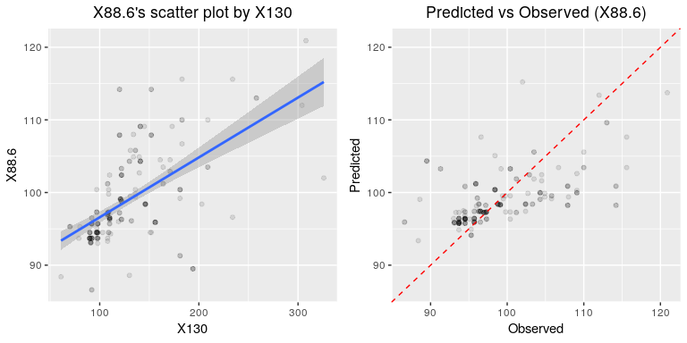

**[ mpfi ]**

Simple Linear Model Information

```
 Residual standard error: 6 on 202 degrees of freedom
 Multiple R-squared:  0.15627,  Adjusted R-squared:  0.1521
 F-statistic: 37 on 1 and 202 DF,  p-value: 4.86728594206892e-09
```

Coefficients:

Simple Linear Model coefficients : mpfi

|  | Estimate | Std. Error | t value | Pr(>\|t\|) |
| --- | --- | --- | --- | --- |
| (Intercept) | 93.81 | 0.90 | 103.86 | 0 |
| mpfi | 1.18 | 0.19 | 6.12 | 0 |

Visualization:

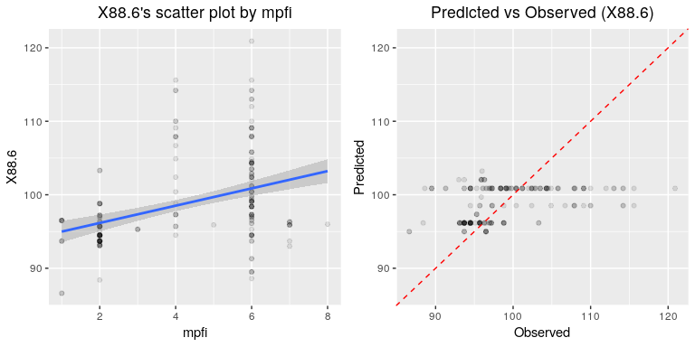

**[ X3.47 ]**

Simple Linear Model Information

```
 Residual standard error: 5 on 202 degrees of freedom
 Multiple R-squared:  0.25539,  Adjusted R-squared:  0.25171
 F-statistic: 69 on 1 and 202 DF,  p-value: 1.27006434799449e-14
```

Coefficients:

Simple Linear Model coefficients : X3.47

|  | Estimate | Std. Error | t value | Pr(>\|t\|) |
| --- | --- | --- | --- | --- |
| (Intercept) | 93.08 | 0.78 | 119.71 | 0 |
| X3.47 | 0.29 | 0.04 | 8.32 | 0 |

Visualization:

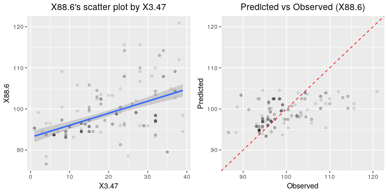

**[ X2.68 ]**

Simple Linear Model Information

```
 Residual standard error: 6 on 202 degrees of freedom
 Multiple R-squared:  0.03922,  Adjusted R-squared:  0.03447
 F-statistic: 8 on 1 and 202 DF,  p-value: 0.00451790683608701
```

Coefficients:

Simple Linear Model coefficients : X2.68

|  | Estimate | Std. Error | t value | Pr(>\|t\|) |
| --- | --- | --- | --- | --- |
| (Intercept) | 96.05 | 1.05 | 91.90 | 0 |
| X2.68 | 0.13 | 0.05 | 2.87 | 0 |

Visualization:

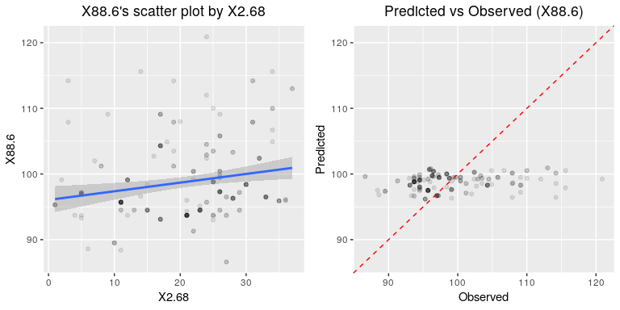

**[ X9 ]**

Simple Linear Model Information

```
 Residual standard error: 6 on 202 degrees of freedom
 Multiple R-squared:  0.0621,   Adjusted R-squared:  0.05746
 F-statistic: 13 on 1 and 202 DF,  p-value: 0.000325305709262263
```

Coefficients:

Simple Linear Model coefficients : X9

|  | Estimate | Std. Error | t value | Pr(>\|t\|) |
| --- | --- | --- | --- | --- |
| (Intercept) | 95.00 | 1.12 | 84.97 | 0 |
| X9 | 0.38 | 0.10 | 3.66 | 0 |

Visualization:

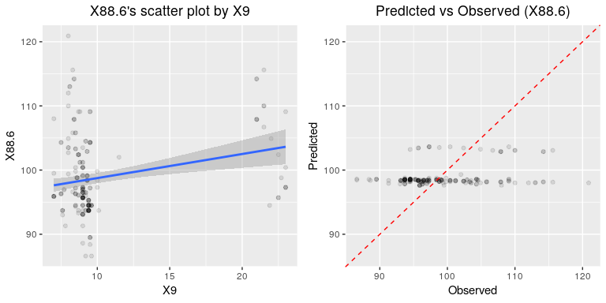

**[ X111 ]**

Simple Linear Model Information

```
 Residual standard error: 6 on 202 degrees of freedom
 Multiple R-squared:  0.01015,  Adjusted R-squared:  0.00525
 F-statistic: 2 on 1 and 202 DF,  p-value: 0.151558027295853
```

Coefficients:

Simple Linear Model coefficients : X111

|  | Estimate | Std. Error | t value | Pr(>\|t\|) |
| --- | --- | --- | --- | --- |
| (Intercept) | 99.89 | 0.86 | 116.26 | 0.00 |
| X111 | -0.03 | 0.02 | -1.44 | 0.15 |

Visualization:

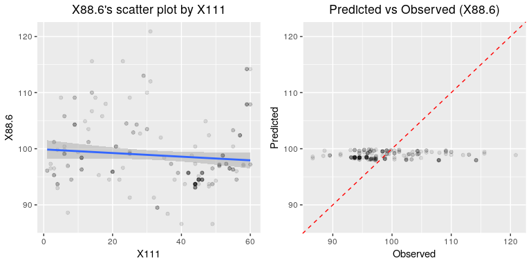

**[ X5000 ]**

Simple Linear Model Information

```
 Residual standard error: 6 on 202 degrees of freedom
 Multiple R-squared:  0.12131,  Adjusted R-squared:  0.11696
 F-statistic: 28 on 1 and 202 DF,  p-value: 3.30994568767923e-07
```

Coefficients:

Simple Linear Model coefficients : X5000

|  | Estimate | Std. Error | t value | Pr(>\|t\|) |
| --- | --- | --- | --- | --- |
| (Intercept) | 104.02 | 1.06 | 97.78 | 0 |
| X5000 | -0.39 | 0.07 | -5.28 | 0 |

Visualization:

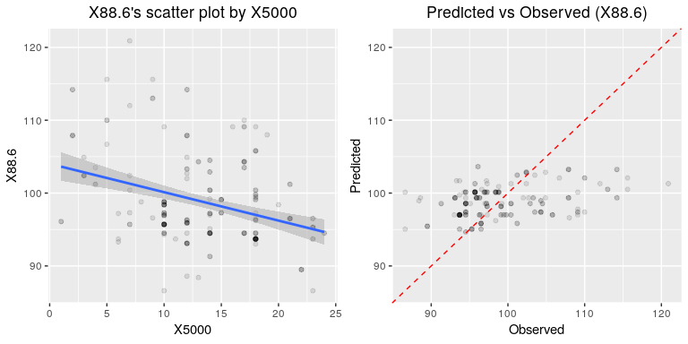

**[ X21 ]**

Simple Linear Model Information

```
 Residual standard error: 5 on 202 degrees of freedom
 Multiple R-squared:  0.23005,  Adjusted R-squared:  0.22624
 F-statistic: 60 on 1 and 202 DF,  p-value: 3.92464322771579e-13
```

Coefficients:

Simple Linear Model coefficients : X21

|  | Estimate | Std. Error | t value | Pr(>\|t\|) |
| --- | --- | --- | --- | --- |
| (Intercept) | 109.88 | 1.47 | 74.61 | 0 |
| X21 | -0.44 | 0.06 | -7.77 | 0 |

Visualization:

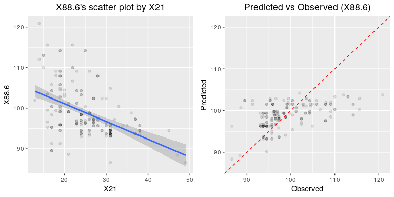

**[ X27 ]**

Simple Linear Model Information

```
 Residual standard error: 5 on 202 degrees of freedom
 Multiple R-squared:  0.30569,  Adjusted R-squared:  0.30226
 F-statistic: 89 on 1 and 202 DF,  p-value: 9.95332363411433e-18
```

Coefficients:

Simple Linear Model coefficients : X27

|  | Estimate | Std. Error | t value | Pr(>\|t\|) |
| --- | --- | --- | --- | --- |
| (Intercept) | 113.59 | 1.61 | 70.72 | 0 |
| X27 | -0.48 | 0.05 | -9.43 | 0 |

Visualization:

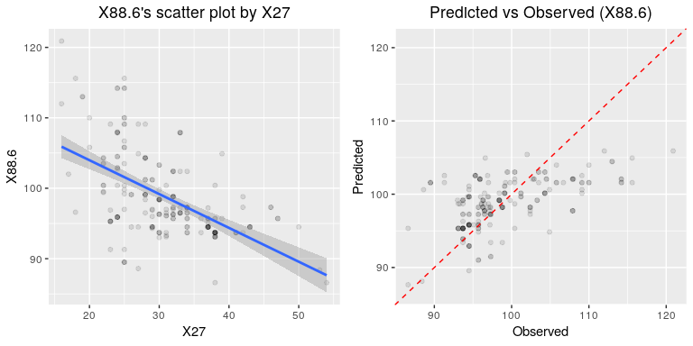

**[ X13495 ]**

Simple Linear Model Information

```
 Residual standard error: 6 on 202 degrees of freedom
 Multiple R-squared:  0.09317,  Adjusted R-squared:  0.08868
 F-statistic: 21 on 1 and 202 DF,  p-value: 9.02233802702404e-06
```

Coefficients:

Simple Linear Model coefficients : X13495

|  | Estimate | Std. Error | t value | Pr(>\|t\|) |
| --- | --- | --- | --- | --- |
| (Intercept) | 101.98 | 0.80 | 127.03 | 0 |
| X13495 | -0.03 | 0.01 | -4.56 | 0 |

Visualization:

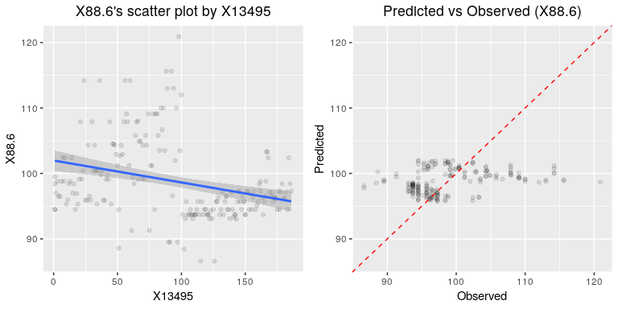

### 4.1.2 Grouped Categorical Variables

There is no categorical variable.

## 4.2 Grouped Relationship Between Variables

### 4.2.1 Grouped Correlation Coefficient

```
Numerical target variables are not supported.
```

### 4.2.2 Grouped Correlation Plot of Numerical Variables

```
Numerical target variables are not supported.
```